# Lab 12: A Bite of R and ggplot2

CMSC471: Introduction to Information Visualization (Spring 2025)

04/30/2025

This lab introduces you to the basics of data visualization using R. You’ll learn how to transform raw data into meaningful visual insights using R packages. By the end of this session, you’ll understand how to create and customize various types of plots. The dataset comes from `https://www.kaggle.com/datasets/schmoyote/coffee-reviews-dataset?select=simplified_coffee.csv`. Or you can download it [**here**](https://fumeng-yang.github.io/CMSC471/handouts/simplified_coffee.csv).

## Part 1: Setup

### Understanding R and RStudio

Imagine you’re in a kitchen. Python might be like a Swiss Army knife – good at many things. Java might be like a food processor – great for specific tasks. R? R is like having a complete chef’s kitchen specifically designed for working with data analysis. It was built from the ground up with data analysis and visualization in mind. This is [a comparison](https://fumeng-yang.github.io/CMSC471/handouts/lab12-RvsPython.html) between R and Python.

RStudio is like a sophisticated workbench for R. It provides a user-friendly interface where you can write code, view your data, see your plots, and manage your files all in one place. RStudio is the well-organized desk where you keep that calculator along with all your other tools neatly arranged.

Like the Tableau lab, you are two options **(1)** download and install R and R Studio, or **(2)** using a cloud service (limited functions).

My tutorial is based on my local RStudio, but this lab should be simple enough for you to finish on a cloud service.

### Option 1: Installing R and RStudio

Let’s open [RStudio Downloads](https://posit.co/download/rstudio-desktop/), which directs us to insatll R first.

[figure not shown]

RStudio setup page

1. **Install R**: Navigate to [CRAN](https://cran.r-project.org/) (Comprehensive R Archive Network). CRAN is like an app store for R – it’s where you get both R itself and many of its add-on packages. Choose your operating system and follow the installation instructions. Don’t worry about all the technical terms you see during installation; the default options are fine for our purposes.
2. **Install RStudio**: After installing R, visit [RStudio Downloads](https://posit.co/download/rstudio-desktop/). RStudio needs R to work, similar to how a web browser needs an internet connection. Download and install the free desktop version, again using default settings.
3. **Open RStudio**:

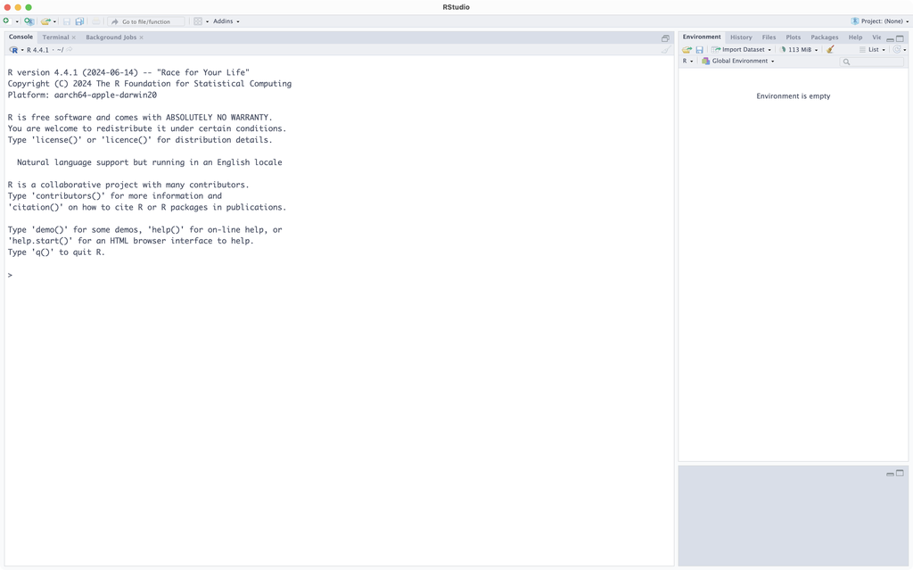

Open RStudio

#### Creating a new project

Before I can explain everything, let’s first create a (R) new project. Think of an R Project like a dedicated workspace for your analysis. It’s like having a separate desk for each project you’re working on. You won’t mix up files from different projects. Your code will work the same way on any computer and the paths are much easier to handle.

**1. Click File → New Project**

[figure not shown]

Create a new project 1

**2. Choose one of the options**

Here I recommend ‘New Directory’, and put the new folder in your `CMSC471` folder.

[figure not shown]

Create a new project 2

Then follow the steps. Note I use my existing `lab12-full` directory and I have some files which you may not have.

**3. Create a RMarkdown file**

RMarkdown is like having a lab notebook, code editor, and report writer all in one place (similar to Jupyter notebook). It combines code editing, its output, and report writing together.

[figure not shown]

Create a new RMarkdown

Type in a title name (e.g., “Lab 12”) and continue.

### Option 2: Using Posit cloud

1. **Log into Posit**:

Go to https://posit.cloud/ (open the link in a new tab) and use your Google account to log in (or you can register an account).

[figure not shown]

Get started Posit

2. **Create a new project**:

[figure not shown]

Get started on Posit

You should be able to see a similar interface.

[figure not shown]

Posit project

**3. Create a RMarkdown file**

RMarkdown is like having a lab notebook, code editor, and report writer all in one place (similar to Jupyter notebook). It combines code editing, its output, and report writing together. It might take some installation time here.

Type in a title name (e.g., “Lab 12”) and continue.

[figure not shown]

Posit project

### Understanding the RStudio interface

I will use my local R studio in the instructions. If you are using Posit cloud, you can click on the button next to **“Posit Cloud”** (top left) to hide the menu to get a similar interface.

[figure not shown]

RStudio Interface

Although you can changes the layout later, the RStudio interface is divided into four main panels:

- **Editor** (top-left): This is your primary workspace where you write and edit your R code.
- **Environment** (top-right): Shows what data and variables you have available.
- **Console** (bottom-left): This serves as a command line tool.
- **Output** (bottom-right): A multipurpose area showing plots and more.

The new RMarkdown contains template code

[figure not shown]

### Installing required packages

In R, packages are collections of additional functions and tools that extend R’s capabilities. The tidyverse is a collection of packages (including ggplot2) that work together for data science, while ggdist provides specialized visualization tools for statistical distributions.

In **console**, type in these lines and hit “Enter”

```r
install.packages("tidyverse")
install.packages("ggdist")
```

When you run these commands, you might see a lot of text output, including some in red. Don’t panic! This is normal during installation. The red text usually just means R is giving you additional information or warnings, not necessarily errors. Think of it as R keeping you informed about what it’s doing behind the scenes. You can look at “the basic grammar below” while waiting for the packages being installed.

[figure not shown]

RStudio Interface

After you finish, let’s load the packages we need in our RMarkdown. Put these in the `setup` block, make sure you cursor is in that block, and click on “Run” it. You can remember the shortcut and then use the shortcut next time.

```r
library(tidyverse)
library(ggdist)
```

[figure not shown]

Run a R block

### The basic grammar

R has a unique way of writing code that might look different from other languages you’ve seen. Let’s break it down:

1. **The assignment operator (`<-`)**

```r
my_number <- 42
```

This is like saying “take 42 and put it in a box labeled ‘my_number’”. You could use “=” too.

2. **Functions and arguments**

```r
mean(numbers, na.rm = TRUE)
```

Think of this like a recipe:

- `mean` is what you want to do
- `numbers` is what you want to do it to
- `na.rm = TRUE` is a special instruction (ignore missing values)

### The Grammar of data (tidyverse)

The tidyverse is like a set of grammar rules for working with data. It makes data manipulation feel like writing plain English:

```r
data %>%
  select(age, height) %>%
  filter(age > 20) %>%
  arrange(height)
```

This reads like a set of instructions:

1. Take this data, then
2. Select the age and height columns, then
3. Keep only rows where age is over 20, then
4. Arrange everything by height

## Part 2: Loading data

### Understanding data structure

Before we work on visualization, let’s understand how R handles data. In R, data is typically organized in what’s called a data frame or tibble (tidyverse’s enhanced version of a data frame). Think of it as a spreadsheet where:

- Each column represents a variable (like height, weight, age)
- Each row represents an observation or case
- The intersection of a row and column contains a specific value

**Delete** all the template code except for our `setup` chunck. You can quickly **insert** a new chunk into your file with

- the keyboard shortcut Ctrl + Alt + I (Mac: Cmd + Option + I)
- the `Add Chunk` command in the editor toolbar

### Loading your data

Let’s use a new chunck for the code below.

```r
# Read the CSV file
data <- read_csv("simplified_coffee.csv")

# Look at the first few rows
head(data)
```

The `read_csv()` function is your data importer. It takes data from a CSV file (which you might have created in Excel or downloaded from somewhere) and brings it into R in a format R can understand. The `<-` operator is like an arrow pointing to where you want to store the data – in this case, in an object called `data`.

- The dimensions of your dataset (how many rows and columns)
- The names of all variables
- The type of data in each column (character, numeric, etc.)
- A few sample values from each column

**Run this chunck, and we can get the output of this chunck beneath it.**

[figure not shown]

Loading data

### Understanding data types

R uses different data types for different kinds of information:

- `chr` (character): Text data, like names or categories
- `dbl` (double): Numeric data with decimal points
- `int` (integer): Whole numbers
- `fct` (factor): Categorical data with predefined levels
- `date`: Date values

Understanding these types is crucial because they affect what kinds of visualizations you can create. For example, you can create a scatter plot with two numeric variables, but not with two text variables.